### *Causal inference beyond the potential outcome framework*

# Pearl's graphical theory of causality

Information Systems Seminar @ HU Berlin

Gerome Wolf, Gleb Zhidkov, Nesrin Othmann, and Mariia Semenenko

# Outlay

- Motivation
- Three-level causal hierarchy
- Pearl's **graphical theory** of causality
- (1) **Definition** of a (causal) model
- (2) Causal **assumptions**
- (3) **Identification**
- (4) **Estimation**
- (5) **Robustness** checks
- Conclusions
- Practical example: Hotel booking cancellations

# Motivation

**Causality** $\neq$ **correlation and prediction**

[figure not shown]

## Objective of causal inference

- Identify and estimate causal effect
- confounder-free point estimates capturing the difference in outcomes between treated and non-treated observations that is solely attributable to a specific intervention
- observational vs. experimental data
- typical sources of confoundingness / "endogeneity"
1. Omitted variable $\rightarrow$ OVB, remedy: include proxy variable
2. Measurement error in independent variable $\rightarrow$ attenuation bias, remedy: structural model
3. Simultaneity (regressors correlated with structural error term of dependent variable)
   - price and quantity are determined simultaneously in equilibrium through demand and supply
   - more unknowns than equations, impossible to identify causal effect of price on quantity within this system

### Popular techniques

1. Linear regression
2. Propensity score matching
3. Instrumental variables
4. Difference-in-differences
5. Regression discontinuity design
6. Structural vectorautoregressive models for time series

### Potential outcome framework & "counterfactual"

#### What is the causal effect of hospitalization?

- naively comparing group means yields that people who went to hospital were, on average, less healthy than others who did not go to hospital  
  $\rightarrow$ don't go to hospital!
- self-selection!

*Recall the potential outcome framework of Neyman-Rubin (1923, 1974) and Rosenbaum (1983):*

The observed outcome, $Y_i$, can be written in terms of potential outcomes as

\begin{align*} Y_i &= \begin{cases} Y_{1i},& \text{if } D_i = 1\\ Y_{0i}, & \text{if } D_i = 0\\ \end{cases} \end{align*}\begin{align*} &= Y_{0i} + (Y_{1i} - Y_{0i}) D_i \end{align*}\begin{align*} \underbrace{\mathop{\mathbb{E}}[Y_{i}|D_i = 1] - \mathop{\mathbb{E}}[Y_{i}|D_i = 0]}_\text{Observable difference in mean outcomes} = \underbrace{\mathop{\mathbb{E}}[Y_{1i}|D_i = 1] - \color{red}{\mathop{\mathbb{E}}[Y_{0i}|D_i = 1]}}_\text{Average treatment effect on the treated} + \underbrace{\mathop{\mathbb{E}}[Y_{0i}|D_i = 1] - \mathop{\mathbb{E}}[Y_{0i}|D_i = 0]}_\text{Selection bias} \end{align*}

### Pearl's claim (in our words):

> Even though the causal interpretation inherited from appropriate methods relying on well-known statistical properties may be justified, some objects, especially the "counterfactual", within this framework are subject to a lack of mathematical rigor, formalisation and identification.

### General note:

- treatment may be continuous or discrete
- $\mathop{\mathbb{E}}(\mathord{\cdot}) \Leftrightarrow P(\mathord{\cdot})$ for discrete dependent variable

### (Linear) structural model

#### Graphical representation

[figure not shown]

$X$: hours studied  
$Y$: points achieved

- correlation (dashed lines)
- causal relationship (solid line)
- directionality (arrow)
- missing edge between $u_X$ and $u_Y$: independence

#### Analytical representation

\begin{align*} f_{X}(u_{X}) &= X = u_X \\ f_{Y}(X, u_Y) &= Y = \beta X + u_Y \end{align*}

- ambiguous relationship (e.g. rearrange $X$ in terms of $Y$)
  - possible remedy: IV estimation to inject directionality through exclusion assumptions and is operationalised through 2SLS which uncorrelates the error terms through the endogeneous variable
- idea: combine graphical and analytical representations in a complementary way

### The core

\begin{align*} Cov(X, u_Y) &= \mathop{\mathbb{E}}[X'\epsilon] \stackrel{!}{=} 0 \quad \text{in linear regression}\\ \\ Cov(X, u_Y) &= \mathop{\mathbb{E}}[X'\epsilon] = 0 \quad \text{in structural equation modelling} \end{align*}

- in linear regression: an assumption **by construction** in form of an optimality condition that comes out of the minimization of an L2 norm loss function

#### Pearl (An Introduction to Causal Inference, 2010):

> "...parallels the celebrated “orthogonality” condition in linear models, $Cov(X,u_Y) = 0$, which has been used routinely, often thoughtlessly, to justify the estimation of structural coefficients by regression techniques."

### Preliminary conclusions

- counterfactual model and Pearl's graphical theory of causality are **fully compatible** with each other and are therefore **complementary and not rivalling** concepts
- no specific functional form required to achieve identification and estimation
- importance of collider (i.e. endogeneous) variables $\rightarrow$ **back-door criterion**
- domain knowledge, rigor notation and proper definition of the counterfactual:
  - $Y_X(u) = Y_{M_{X}}(u)$ ("value of $Y$ in unit $u$ had $X$ been $x$")
- use graphs to **explicitly** encode all assumptions and **assist** the researcher to **structure** the process from problem to solution

## The three level causal hierarchy of Pearl

**What does a purchase of product A tells about the likelihood of a consumer purchasing product B?**

[figure not shown]

Definition of the associational layer

- Assumes purely statistical relationships
- No causal information is required
- $P(y|x)$ the probability of event $Y = y$ is equal to $p$, given that we observe event $X=x$
- Can be computed using Bayesian Networks

**What if we increase the price, how consumer behavior will change?**

[figure not shown]

Definition of the intervention layer

- Requires changing or intervening the situation we observe
- $P(y|do(x), z)$, which denotes the probability of event $Y = y$ given that we intervene and set the value of $X$ to $x$ and subsequently observe event $Z=z$
- Can be estimated from randomized trials using Causal Bayesian Networks

**What would happen had the price been twice its current value?**

[figure not shown]

Definition of the counterfactual layer

- Requires retrospecitve reasoning
- Subsumes questions of Association and Intervention
- $P(y_x|x', y')$ stands for the probability of event $Y$ had $X$ been $x$, given that we actually observed $X$ to be $x'$ and $Y$ to be $y'$
- Can be estimated from functional or structural equation models

**Now you might wonder, how does Intervention differ from Counterfactual level?**

- Intervention: what will happen in the future if you perform an action?
- Counterfactual: what would have happened in the past if you had taken a different action, given that you have information about what actually happened
- An update of the probability in the light of the evidence observed is needed

## Practical example

### Data: Hotel booking cancellations

- Booking information for a city hotel and a resort hotel in Portugal
- 27 data features and nearly 120k rows
- Treatment: `different_room_assigned` (binary)
- Outcome: `is_canceled` (binary)
- Hypothesis: guests assigned a different room are more likely to cancel their hotel stay
- Source: Towards Data Science Article by Siddharth Dixit - [Article](https://towardsdatascience.com/beyond-predictive-models-the-causal-story-behind-hotel-booking-cancellations-d29e8558cbaf) | [GitHub repository](https://github.com/Sid-darthvader/DoWhy-The-Causal-Story-Behind-Hotel-Booking-Cancellations)

```python
dataset_link = (
    'https://raw.githubusercontent.com/Sid-darthvader/'
    'DoWhy-The-Causal-Story-Behind-Hotel-Booking-Cancellations/master/hotel_bookings.csv'
)

dataset = pd.read_csv(dataset_link)
dataset = prepare_booking_cancellation_data(dataset)

dataset.sample(5).T
```

|  | 26101 | 82528 | 24899 | 46652 | 30118 |
| --- | --- | --- | --- | --- | --- |
| hotel | Resort Hotel | City Hotel | Resort Hotel | City Hotel | Resort Hotel |
| is_canceled | False | False | False | True | False |
| lead_time | 38 | 70 | 116 | 43 | 3 |
| arrival_date_month | July | December | May | January | November |
| arrival_date_week_number | 30 | 53 | 23 | 3 | 49 |
| meal | BB | HB | HB | BB | BB |
| country | IRL | FRA | DEU | ESP | PRT |
| market_segment | Online TA | Direct | Offline TA/TO | Online TA | Corporate |
| distribution_channel | TA/TO | Direct | TA/TO | TA/TO | TA/TO |
| is_repeated_guest | 0 | 0 | 0 | 0 | 1 |
| previous_cancellations | 0 | 0 | 0 | 0 | 0 |
| previous_bookings_not_canceled | 0 | 0 | 0 | 0 | 4 |
| booking_changes | 0 | 0 | 0 | 0 | 0 |
| deposit_type | No Deposit | No Deposit | No Deposit | No Deposit | No Deposit |
| days_in_waiting_list | 0 | 0 | 0 | 0 | 0 |
| customer_type | Transient | Transient | Transient | Transient-Party | Transient |
| adr | 179 | 190.78 | 90 | 86.75 | 30 |
| required_car_parking_spaces | 1 | 0 | 0 | 0 | 0 |
| total_of_special_requests | 1 | 2 | 0 | 1 | 2 |
| total_stay | 1 | 4 | 9 | 3 | 1 |
| guests | 2 | 3 | 2 | 2 | 1 |
| different_room_assigned | False | True | False | False | True |

```python
print(
    f'Different room assigned: {100*dataset.different_room_assigned.mean():.2f}% of all bookings\n'
    f'Booking canceled:        {100*dataset.is_canceled.mean():.2f}% of all bookings\n\n'
    f'Total bookings: {dataset.shape[0]}'
)
```

```
Different room assigned: 12.49% of all bookings
Booking canceled:        37.04% of all bookings

Total bookings: 119386
```

## *5 Steps of Causal inference:*

## (1) Definition of a general model

Let's start with a general question: **when is a causal effect identifiable?**

According to Pearl's definition (2010, 12),

> A causal effect is identifiable when its estimation depends solely on the distribution of observed variables and not on the model used for the estimation (for any model that satisfies assumptions encoded in the causal graph).

In other words, **the (choice of) model does not matter as long as assumptions are satisfied!**

Hence, the first step of causal inference is to **define a general model** which is not restricted to a specific functional form.

[figure not shown]

The concept of a general model is integral to understand the Pearl's framework of causal inference!

Yet in practice one still has to assume some functional form when estimating the causal effect.

## (2) Causal assumptions → causal graph

```python
make_graph(['AB'])
```

[output not shown]

## Causal graph

- A **directed graph** where each *node* represents a variable and each *arrow* depicts a relationshio between two variables
- Our **expert belief** about the data generating process; assumptions encoded in missing connections between nodes

### D-separation (Pearl, 1988)

- A criterion to identify **conditional independence** between two variables: $ X \perp\!\!\!\perp Y \mid S $.
- $X$ and $Y$ are d-separated whenever all possible paths from $X$ to $Y$ are **blocked** *(see next slide)*.
- We should test causal assumptions: if $X$ and $Y$ are d-separated, they should be uncorrelated.
- (Definition.) A path from $X$ to $Y$ is said to be blocked if either (i) it contains at least one arrow-emitting node that is in $S$, or (ii) it contains at least one collision node that is outside $S$ and has no descendant in $S$.

```python
make_graph(**graph1)
```

[figure not shown]

- The path from $A$ to $C$ is **unblocked**, and $C$ can be reached from $A$
- Intuition: an intervention in A can have a causal effect on C
- The path from $D$ to $F$ is **blocked by conditioning** on $E$
- $\Rightarrow D \perp\!\!\!\perp F \mid S=\{E\}$
- Intution: whatever happens in $D$, it can't have causal effect on $F$ because value of $E$ is fixed, and there is no other path from $D$ to $F$

```python
make_graph(**graph1)
```

[figure not shown]

### Back to the marketing application:

```python
causal_graph = """digraph {
different_room_assigned[label="Different Room Assigned"];
is_canceled[label="Booking Cancelled"];
booking_changes[label="Booking Changes"];
previous_bookings_not_canceled[label="Previous Booking Retentions"];
days_in_waiting_list[label="Days in Waitlist"];
lead_time[label="Lead Time"];
market_segment[label="Market Segment"];
country[label="Country"];
U[label="Unobserved Confounders"];
is_repeated_guest;
total_stay;
guests;
meal;
market_segment -> lead_time;
lead_time->is_canceled; country -> lead_time;
different_room_assigned -> is_canceled;
U -> different_room_assigned; U -> lead_time; U -> is_canceled;
country->meal;
lead_time -> days_in_waiting_list;
days_in_waiting_list ->is_canceled;
previous_bookings_not_canceled -> is_canceled;
previous_bookings_not_canceled -> is_repeated_guest;
is_repeated_guest -> is_canceled;
total_stay -> is_canceled;
guests -> is_canceled;
booking_changes -> different_room_assigned; booking_changes -> is_canceled;
}"""

model = dowhy.CausalModel(
    data=dataset,
    graph=causal_graph.replace("\n", " "),
    treatment='different_room_assigned',
    outcome='is_canceled')
```

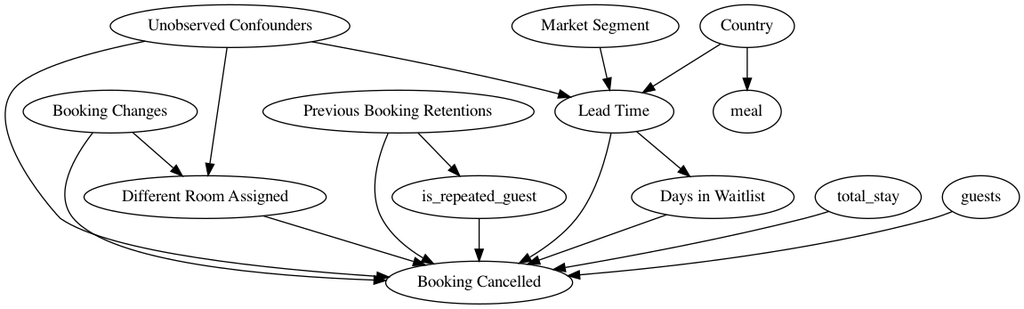

```python
model.view_model()
display(Image(filename="causal_model.png"))
```

## (3) Identification

(3) **Identifying** the estimand by checking whether explicit assumptions allow to solve for the parameter(s) of interest as function(s) of exogeneous variables

### Methods for covariate selection:

- back-door criterion
- front-door criterion
- instrumental variables
- mediation techniques

### Back-door criterion

- Isolate (by conditioning) all paths through which the data-generating process can influence the outcome $Y$ through a backward path from $X$
- For a causal path $X\!\longrightarrow\!Y$: we must go backwards from $Y$ to $X$
- (Definition.) Find a set of nodes 𝑆 that is "sufficient for adjustment" s.t.  
  (i) no element of 𝑆 is a descendant (child) of 𝑋, and  
  (ii) elements of 𝑆 block all back-door paths from 𝑋 to 𝑌

```python
make_graph(**graph2) # adjusted from Pearl (2010, 15)

# Z1, Z2, Z3 are confounders
# X is the intervention variable
# Y is the target
```

[figure not shown]

- What would be a sufficient set for the causal graph shown above?
- Clearly, $Z_3$ blocks the back-door path $X\!\longleftarrow\!Z_3\!\longrightarrow\!Y$ (we walk backwards from $X$ to $Z_3$ and then forwards to $Y$)

```python
make_graph(**graph2, highlight=['O'])
```

[figure not shown]

```python
make_graph(**graph2, highlight=['O', 'A'])
```

[figure not shown]

Finally, holding $S = \{Z_1, Z_3\}$ constant, we can estimate the "true" causal effect of $X$ on $Y$.

More formally, the causal effect expression can be rewritten as $P(Y|do(X)) = \sum_{S} P(Y|X=x, S=s)P(S=s)$, where $S$ denotes the conditioning set.

The identification of a sufficient set to condition on is what happens in the `model.identify_effect()` step of the doWhy-pipeline.

### Back to the marketing application:

```python
identified_estimand = model.identify_effect(proceed_when_unidentifiable=True)
pretty_estimand_output(identified_estimand)

# https://github.com/microsoft/dowhy/issues/198#issuecomment-735269793
# 1 back-door estimand in dowhy==0.4; 257 in dowhy==0.5
```

```
A total of 257 estimands identified for this model.
First back-door estimand:

> Unconfoundedness assumptions:
If U→{different_room_assigned} and U→is_canceled then P(is_canceled|different_room_assigned,booking_changes,lead_time,U) = P(is_canceled|different_room_assigned,booking_changes,lead_time)

> Estimand:
```

$\displaystyle \frac{d}{d \left[\begin{matrix}different_{room assigned}\end{matrix}\right]} Expectation\left(is_{canceled|booking changes,lead time}\right)$

## (4) Estimation

### Target effect

- ATE: Average Treatment Effect
- ATT: ATE on Treated: those who were assigned a different room
- ATC: ATE on Control: those who were not assigned a different room
- ATE = P(customer cancels if a different room assigned) – P(customer cancels if no different room assigned)
- ATE = observable effect – counterfactual effect
- If bias=0, then ATE = observable effect

```python
with warnings.catch_warnings():
    warnings.simplefilter('ignore')

    estimate = model.estimate_effect(
        identified_estimand,
        method_name="backdoor.propensity_score_stratification",
        target_units="ate")

print(estimate)
```

```
*** Causal Estimate ***

## Identified estimand
Estimand type: nonparametric-ate

## Realized estimand
b: is_canceled~different_room_assigned+meal+booking_changes+total_stay+days_in_waiting_list+guests+lead_time+previous_bookings_not_canceled+country+market_segment+is_repeated_guest
Target units: ate

## Estimate
Mean value: -0.3346064358628692
```

Interpretation: On average, hotel bookings are 33.5% less likely to be canceled if a guest has been assigned a different room when chosen during the original booking.

### How is this possible?

- 1) wrong assumptions encoded in the graph
- 2) counterfactual > observable effect
- 3) hotels discriminate against customers less likely to cancel their trip (e.g. business travelers)
- 4) real-world data

```python
display(pd.crosstab(dataset.different_room_assigned, dataset.is_canceled))
display(pd.crosstab(dataset.different_room_assigned, dataset.is_canceled, normalize='index')) # row=100%
```

| is_canceled different_room_assigned | False | True |
| --- | --- | --- |
| False | 61051 | 43418 |
| True | 14115 | 802 |

| is_canceled different_room_assigned | False | True |
| --- | --- | --- |
| False | 0.584393 | 0.415607 |
| True | 0.946236 | 0.053764 |

## (5) Robustness checks

### Robustness checks / Model refutation:

- Adding a Random Common Cause
- Placebo Treatment
- Dummy Outcome
- Addding a Unobserved Common Causes
- Data Subsets Validation
- Bootstrap Validation

```python
refuter = CausalRefuter(**refutation_config)
refuter.refute(model, identified_estimand, estimate)
```

```
random_common_cause: Effect should not change significantly -- PASSED with tolerance of +/- 0.1
effect: -0.34 -> -0.34

placebo_treatment_refuter: Effect should go to zero -- PASSED with tolerance of +/- 0.1
effect: -0.34 -> 0.00

dummy_outcome_refuter: Effect should go to zero -- PASSED with tolerance of +/- 0.1
effect: -0.34 -> 0.00

data_subset_refuter: Effect should not change significantly -- PASSED with tolerance of +/- 0.1
effect: -0.34 -> -0.34

bootstrap_refuter: Effect should not change significantly -- PASSED with tolerance of +/- 0.1
effect: -0.34 -> -0.34
```

The effects change exactly as expected compared to the original model; this is often not the case. It is up to the analyst to decide what deviance from the expected effect change is to be expected.

## Conclusions

### Then why is Pearl's framework so unknown/unpopular?

- Difficulty for/reluctance of "traditionally" trained statistician to leave their parametric/functional world of probability calculus
- Unawareness of structural equations modelling
- Missing discipline to clearly formulate experiential knowledge as causal assumptions in a scientific notation
- No standardized notation

### Outlook: *Causal inference beyond the potential outcome framework*

- A very broad topic with a lot of underlying theory
- Cross-sectional causal inference $\neq$ dynamic causality (time series, stationarity!)
- Dynamic causality: causal inference & treatment ~ impulse response functions from e.g. SVAR models
- Classical research questions from macroeconomics, e.g. causal effects of monetary policy on GDP, consumption etc. (Romer-Romer shocks, 2004)

# Bibliography

- Angrist, J., G. Imbens, and D. Rubin (1996): “Identification of causal effects using instrumental variables (with comments),” Journal of the American Statistical Association, 91, 444–472.
- Dixit, S. (2020) Beyond Predictive Models: The Causal Story Behind Hotel Booking Cancellations. Retrieved on 09.12.2020 https://towardsdatascience.com/beyond-predictive-models-the-causal-story-behind-hotel-booking-cancellations-d29e8558cbaf
- Neyman, J. (1923): “On the application of probability theory to agricultural experiments. Essay on principles. Section 9,” Statistical Science, 5, 465–480.
- Pearl, J. (2018) The Seven Tools of Causal Inference with Reflections on Machine Learning. https://ftp.cs.ucla.edu/pub/stat_ser/r481.pdf
- Pearl, J. (2010) An Introduction to Causal Inference https://ftp.cs.ucla.edu/pub/stat_ser/r354-corrected-reprint.pdf
- Pearl, J. (2000) Causality: Models, Reasoning, and Inference. Chapter 1 http://bayes.cs.ucla.edu/BOOK-2K/
- Rosenbaum, P. and D. Rubin (1983): “The central role of propensity score in observational studies for causal effects,” Biometrika, 70, 41–55.
- Rubin, D. (1974): “Estimating causal effects of treatments in randomized and nonrandomized studies,” Journal of Educational Psychology, 66, 688–701.
- Sharma, A. and Kiciman, E. (2020) DoWhy: An End-to-End Library for Causal Inference. https://arxiv.org/abs/2011.04216
- Qingyuan Zhao & Trevor Hastie (2019) Causal Interpretations of Black-Box Models, Journal of Business & Economic Statistics, DOI: 10.1080/07350015.2019.1624293